# 第1章 回帰モデルとスパース推定

Osamu, MORIMOTO

2023-10-12

## 4. 多重共線性があるケース

### 準備

最初にこれから使用するパッケージを一通り呼び出しておく。

```r
if (!require("pacman")) {install.packages("pacman")} # パッケージ管理
pacman::p_load(
  conflicted,   # 関数名の衝突防止
  tidyverse,    # モダンなデータ操作
  glmnetUtils,  # 正則化回帰。テキストと違うが、こちらの方がformulaで書けるのでこちらを使う
  withr,        # 乱数種固定
  summarytools, # データの概要把握（EDA）
  GGally,       # データの概要把握（EDA）
  broom,        # 回帰の結果をtidyにする
  car           # VIFの算出
  )
```

情報量規準の関数も定義しておく。

```r
ic_glmnet <- function(glmnet_model) {
  tLL <- glmnet_model$nulldev - deviance(glmnet_model)
  k <- glmnet_model$df
  n <- glmnet_model$nobs
  sig <- 2
  df <- tibble(
    lambda = glmnet_model$lambda,
    AICc = -tLL + 2 * k + 2 * k * (k + 1) / (n - k - 1),
    BIC = log(n) * k - tLL,
    Cp = (1 - glmnet_model$dev.ratio) * glmnet_model$nulldev / n + 2 * sig^2 / n * k
  )
  return(
    list(
      lambda_AICc_best = df |> slice_min(AICc) |> pull(lambda),
      lambda_BIC_best = df |> slice_min(BIC) |> pull(lambda),
      lambda_Cp_best = df |> slice_min(Cp) |> pull(lambda),
      lambda_AICc = df$AICc,
      lambda_BIC = df$BIC,
      lambda_Cp = df$Cp
      )
    )
  }
```

エラスティックネットのためのλとαの探索関数も定義。

CV版。

```r
# cva.glmnet()の出力を受け取る
get_cv_best_alpha_lambda <- function(cva_model) {
  n <- cva_model$alpha |> length()

  res <- map(
    1:n,
    \(list_no) data.frame(
      best_alpha = cva_model |> pluck("alpha", list_no),
      best_lambda = cva_model |> pluck("modlist", list_no, "lambda"),
      MSE = cva_model |> pluck("modlist", list_no, "cvm")
      )
    ) |>
    list_rbind() |>
    slice_min(MSE) |>
    dplyr::select(best_alpha, best_lambda)

  return(res)
}
```

情報量規準版。

```r
# cva.glmnet()の出力を受け取る
get_ic_best_alpha_lambda <- function(cva_model) {

  n <- cva_model$alpha |>
    length()

  ics <- map(
    1:n,
    \(list_no) cva_model |>
      pluck("modlist", list_no, "glmnet.fit") |>
      ic_glmnet()
    )

  df_ic <- map(
    1:n,
    \(list_no) data.frame(
      best_alpah = cva_model |> pluck("alpha", list_no),
      best_lambda = cva_model |> pluck("modlist", list_no, "lambda"),
      AICc = ics |> pluck(list_no, "lambda_AICc"),
      BIC = ics |> pluck(list_no, "lambda_BIC"),
      Cp = ics |> pluck(list_no, "lambda_Cp")
      )
    ) |>
    list_rbind()

  df_ic_best <- list(
    AICc_best_alpha = df_ic |> slice_min(AICc) |> pull(best_alpah),
    AICc_best_lambda = df_ic |> slice_min(AICc) |> pull(best_lambda),
    BIC_best_alpha = df_ic |> slice_min(BIC) |> pull(best_alpah),
    BIC_best_lambda = df_ic |> slice_min(BIC) |> pull(best_lambda),
    Cp_best_alpha = df_ic |> slice_min(Cp) |> pull(best_alpah),
    Cp_best_lambda = df_ic |> slice_min(Cp) |> pull(best_lambda)
  )

  return(df_ic_best)
 }
```

### EDA

今回は[mtcarsデータセット](https://stat.ethz.ch/R-manual/R-devel/library/datasets/html/mtcars.html)を使います。

1974年の『Motor Trend US』誌から抜粋したデータで、32車種（1973-74年モデル）の燃費と、自動車のデザインと性能に関する10の変数から構成されている。

mpg（燃費）を目的変数とした回帰モデルを作る。

```
mpg : 燃費、Miles/(US) gallon
cyl : シリンダーの数
disp : 排気量（立方インチ）
hp : 馬力
drat : ドライブシャフトの回転数と車軸の回転数との比率（Rear axle ratio）
wt : 重量（1,000ポンド単位）
qsec : 停止状態から約400m進むまでの時間
vs : エンジンのシリンダーの並び方がV-shaped（V型）か、straight（直列型）か、V-shapedが0、straightが1
am : トランスミッションがオートマか、マニュアルか、オートマが0、マニュアルが1
gear : ギアの数
carb : キャブレターの数
```

```r
mtcars |>
  glimpse()
```

```
## Rows: 32
## Columns: 11
## $ mpg  <dbl> 21.0, 21.0, 22.8, 21.4, 18.7, 18.1, 14.3, 24.4, 22.8, 19.2, 17.8,…
## $ cyl  <dbl> 6, 6, 4, 6, 8, 6, 8, 4, 4, 6, 6, 8, 8, 8, 8, 8, 8, 4, 4, 4, 4, 8,…
## $ disp <dbl> 160.0, 160.0, 108.0, 258.0, 360.0, 225.0, 360.0, 146.7, 140.8, 16…
## $ hp   <dbl> 110, 110, 93, 110, 175, 105, 245, 62, 95, 123, 123, 180, 180, 180…
## $ drat <dbl> 3.90, 3.90, 3.85, 3.08, 3.15, 2.76, 3.21, 3.69, 3.92, 3.92, 3.92,…
## $ wt   <dbl> 2.620, 2.875, 2.320, 3.215, 3.440, 3.460, 3.570, 3.190, 3.150, 3.…
## $ qsec <dbl> 16.46, 17.02, 18.61, 19.44, 17.02, 20.22, 15.84, 20.00, 22.90, 18…
## $ vs   <dbl> 0, 0, 1, 1, 0, 1, 0, 1, 1, 1, 1, 0, 0, 0, 0, 0, 0, 1, 1, 1, 1, 0,…
## $ am   <dbl> 1, 1, 1, 0, 0, 0, 0, 0, 0, 0, 0, 0, 0, 0, 0, 0, 0, 1, 1, 1, 0, 0,…
## $ gear <dbl> 4, 4, 4, 3, 3, 3, 3, 4, 4, 4, 4, 3, 3, 3, 3, 3, 3, 4, 4, 4, 3, 3,…
## $ carb <dbl> 4, 4, 1, 1, 2, 1, 4, 2, 2, 4, 4, 3, 3, 3, 4, 4, 4, 1, 2, 1, 1, 2,…
```

```r
mtcars |>
  dfSummary() |>
  print(method = 'render')
```

Data Frame Summary

mtcars

**Dimensions**: 32 x 11  
**Duplicates**: 0

| **No** | **Variable** | **Stats / Values** | **Freqs (% of Valid)** | **Graph** | **Valid** | **Missing** |
| --- | --- | --- | --- | --- | --- | --- |
| 1 | mpg [numeric] | Mean (sd) : 20.1 (6) min ≤ med ≤ max: 10.4 ≤ 19.2 ≤ 33.9 IQR (CV) : 7.4 (0.3) | 25 distinct values |  | 32 (100.0%) | 0 (0.0%) |
| 2 | cyl [numeric] | Mean (sd) : 6.2 (1.8) min ≤ med ≤ max: 4 ≤ 6 ≤ 8 IQR (CV) : 4 (0.3) | 4 : 11 ( 34.4% ) 6 : 7 ( 21.9% ) 8 : 14 ( 43.8% ) |  | 32 (100.0%) | 0 (0.0%) |
| 3 | disp [numeric] | Mean (sd) : 230.7 (123.9) min ≤ med ≤ max: 71.1 ≤ 196.3 ≤ 472 IQR (CV) : 205.2 (0.5) | 27 distinct values |  | 32 (100.0%) | 0 (0.0%) |
| 4 | hp [numeric] | Mean (sd) : 146.7 (68.6) min ≤ med ≤ max: 52 ≤ 123 ≤ 335 IQR (CV) : 83.5 (0.5) | 22 distinct values |  | 32 (100.0%) | 0 (0.0%) |
| 5 | drat [numeric] | Mean (sd) : 3.6 (0.5) min ≤ med ≤ max: 2.8 ≤ 3.7 ≤ 4.9 IQR (CV) : 0.8 (0.1) | 22 distinct values |  | 32 (100.0%) | 0 (0.0%) |
| 6 | wt [numeric] | Mean (sd) : 3.2 (1) min ≤ med ≤ max: 1.5 ≤ 3.3 ≤ 5.4 IQR (CV) : 1 (0.3) | 29 distinct values |  | 32 (100.0%) | 0 (0.0%) |
| 7 | qsec [numeric] | Mean (sd) : 17.8 (1.8) min ≤ med ≤ max: 14.5 ≤ 17.7 ≤ 22.9 IQR (CV) : 2 (0.1) | 30 distinct values |  | 32 (100.0%) | 0 (0.0%) |
| 8 | vs [numeric] | Min : 0 Mean : 0.4 Max : 1 | 0 : 18 ( 56.2% ) 1 : 14 ( 43.8% ) |  | 32 (100.0%) | 0 (0.0%) |
| 9 | am [numeric] | Min : 0 Mean : 0.4 Max : 1 | 0 : 19 ( 59.4% ) 1 : 13 ( 40.6% ) |  | 32 (100.0%) | 0 (0.0%) |
| 10 | gear [numeric] | Mean (sd) : 3.7 (0.7) min ≤ med ≤ max: 3 ≤ 4 ≤ 5 IQR (CV) : 1 (0.2) | 3 : 15 ( 46.9% ) 4 : 12 ( 37.5% ) 5 : 5 ( 15.6% ) |  | 32 (100.0%) | 0 (0.0%) |
| 11 | carb [numeric] | Mean (sd) : 2.8 (1.6) min ≤ med ≤ max: 1 ≤ 2 ≤ 8 IQR (CV) : 2 (0.6) | 1 : 7 ( 21.9% ) 2 : 10 ( 31.2% ) 3 : 3 ( 9.4% ) 4 : 10 ( 31.2% ) 6 : 1 ( 3.1% ) 8 : 1 ( 3.1% ) |  | 32 (100.0%) | 0 (0.0%) |

Generated by summarytools 1.0.1 ([R](https://www.r-project.org/) version 4.3.1)  
2023-10-12

相関も確認。

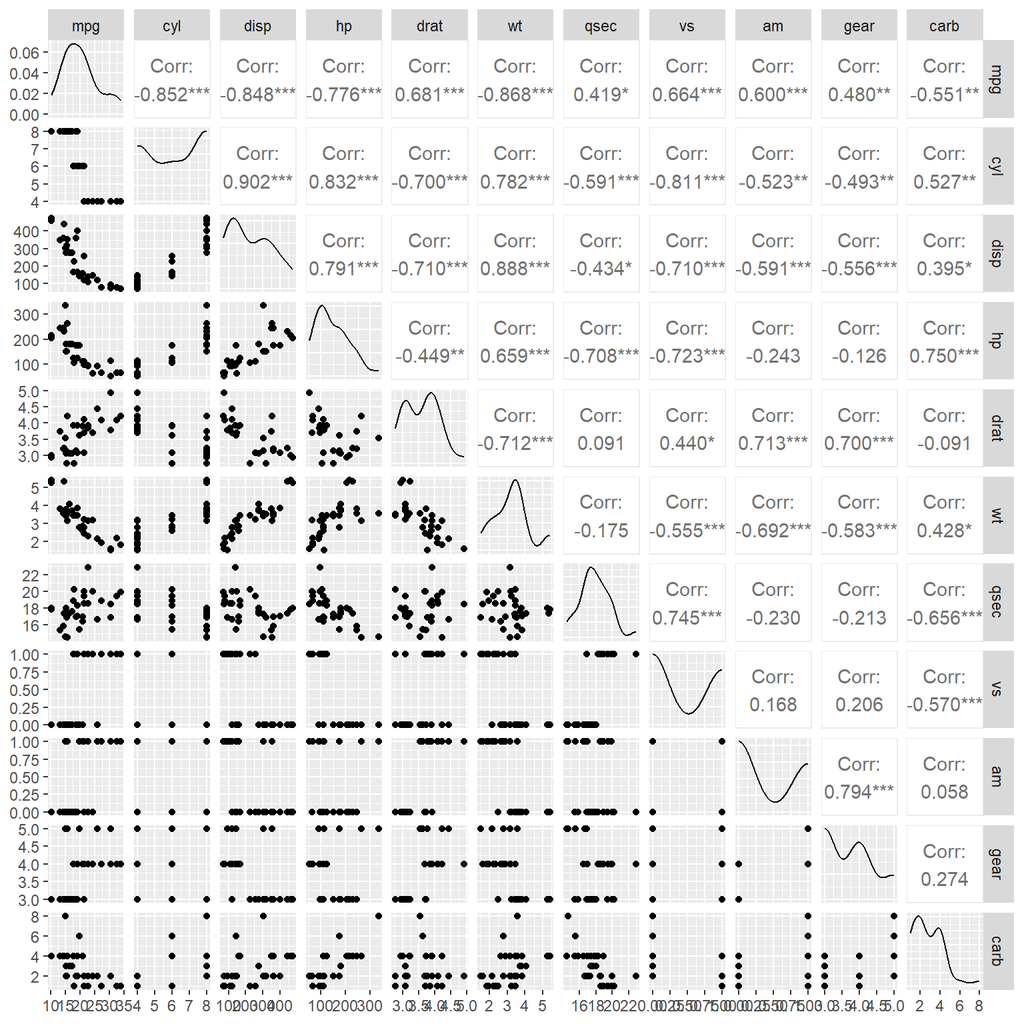

```r
mtcars |>
  GGally::ggpairs()
```

効果が分かりやすいように標準化しておく

```r
mtcars_std <- mtcars |>
  scale() |>
  as.data.frame()
```

### 多重共線性の確認

VIFが10以上であるdisp（排気量）, cyl（シリンダーの数）, wt（重量）に多重共線性の疑いがある。

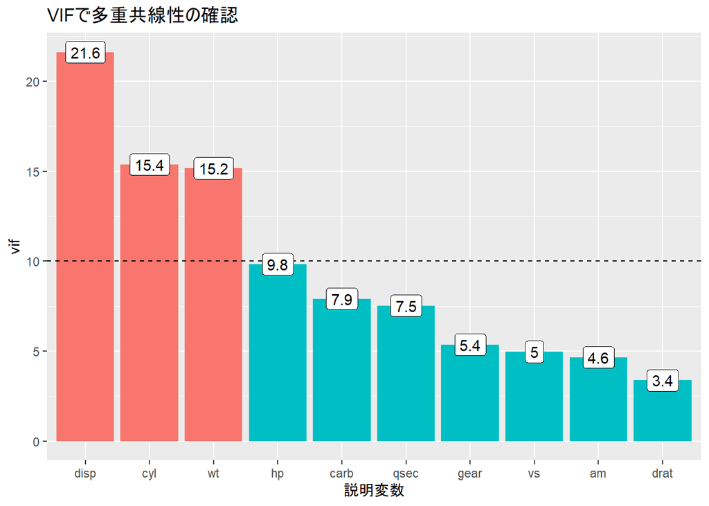

```r
# 回帰モデル
model_lm <- lm(mpg ~ ., data = mtcars_std)

vif <- model_lm |>
  car::vif()

tibble(
  term = names(vif),
  vif = vif
  ) |>
  ggplot(
    aes(
      x = reorder(term, desc(vif)),
      y = vif,
      fill = if_else(vif < 10, "on", "off"),
      label = round(vif, 1)
      )
    ) +
  geom_col() +
  geom_hline(yintercept = 10, linetype = 2) +
  geom_label(fill = "white") +
  theme(legend.position = "none") +
  labs(title = "VIFで多重共線性の確認", x = "説明変数")
```

各種モデル作成

- 線形回帰
- Ridge回帰（CV）
- Ridge回帰（情報量規準）
- LASSO回帰（CV）
- LASSO回帰（情報量規準）
- 適応的LASSO回帰
- エラスティックネット回帰（CV）
- エラスティックネット回帰（情報量規準）

```r
# Ridge回帰 cv
mtcars_cv_ridge <- cv.glmnet(
  mpg ~ ., data = mtcars_std, alpha = 0, nfolds = 5
) |>
  withr::with_seed(2, code = _)

mtcars_fit_ridge_cv <- glmnet(
  mpg ~ .,
  data = mtcars_std,
  alpha = 0,
  lambda =mtcars_cv_ridge$lambda.min
  )

# ridge ic
ridge_lambda_ic <- glmnet(mpg ~ ., data = mtcars_std, alpha = 0) |>
  ic_glmnet() #全部同じ
mtcars_fit_ridge_ic <- glmnet(
  mpg ~ ., data = mtcars_std, alpha = 0, lambda = ridge_lambda_ic$lambda_AICc_best
  )

# LASSO cv
mtcars_cv_lasso <- cv.glmnet(
  mpg ~ .,
  data = mtcars_std,
  alpha = 1,
  nfolds = 5
) |>
  withr::with_seed(2, code = _)

mtcars_fit_lasso_cv <- glmnet(
  mpg ~ .,
  data = mtcars_std,
  alpha = 1,
  lambda =mtcars_cv_lasso$lambda.min
)

# LASSO ic
lasso_lambda_ic <- glmnet(mpg ~ ., data = mtcars_std, alpha = 1) |>
  ic_glmnet()
#AICc, BICとCpで違う
mtcars_fit_lasso_ic_AICc <- glmnet(
  mpg ~ ., data = mtcars_std, alpha = 1, lambda = lasso_lambda_ic$lambda_AICc_best
  )

mtcars_fit_lasso_ic_Cp <- glmnet(
  mpg ~ ., data = mtcars_std, alpha = 1, lambda = lasso_lambda_ic$lambda_Cp_best
  )

# 適応的ラッソ Adaptive Lasso
mtcars_lm_std_coef <- mtcars_std |>
  scale() |>
  as.data.frame() |>
  lm(mpg ~ ., data = _) |>
  tidy() |>
  select(estimate) |>
  slice(-1)

mtcars_alasso <- glmnet(
  mpg ~ .,
  data = mtcars_std,
  alpha = 1,
  penalty.factor = 1 / abs(mtcars_lm_std_coef$estimate),
  lambda = 5 / nrow(mtcars_std)^(3 / 4)
  )

# EN
mtcars_fit_glmnet_L1L2 <- cva.glmnet(
  mpg ~ .,
  data = mtcars_std,
  nfolds = 5
  ) |>
  with_seed(2, code = _)

# EN CVで探索
mtcars_en_cv <- mtcars_fit_glmnet_L1L2 |>
  get_cv_best_alpha_lambda()

mtcars_en_cv #alpha=0なので省略
```

| best_alpha | best_lambda |
| --- | --- |
| 0 | 0.6024763 |

```r
# EN icで探索
mtcars_en_ic <- mtcars_fit_glmnet_L1L2 |>
  get_ic_best_alpha_lambda()

mtcars_en_ic #alpha=1なので省略
```

```
## $AICc_best_alpha
## [1] 1
##
## $AICc_best_lambda
## [1] 0.1210515
##
## $BIC_best_alpha
## [1] 1
##
## $BIC_best_lambda
## [1] 0.1210515
##
## $Cp_best_alpha
## [1] 1
##
## $Cp_best_lambda
## [1] 0.4057166
```

エラスティックネットはCVではalpha=0、情報量規準ではalpha=1となったので以降省略。

偏回帰係数を比較

```r
# 偏回帰係数比較
coefs <- model_lm |>
  broom::tidy() |>
  select(term, estimate) |>
  left_join(
    mtcars_fit_ridge_cv |>
      broom::tidy() |>
      select(term, estimate),
    by = join_by(term)
    ) |>
  left_join(
    mtcars_fit_ridge_ic |>
      broom::tidy() |>
      select(term, estimate),
    by = join_by(term)
    ) |>
  left_join(
    mtcars_fit_lasso_cv |>
      broom::tidy() |>
      select(term, estimate),
    by = join_by(term)
    ) |>
  left_join(
    mtcars_fit_lasso_ic_AICc |>
      broom::tidy() |>
      select(term, estimate),
    by = join_by(term)
    ) |>
   left_join(
    mtcars_fit_lasso_ic_Cp |>
      broom::tidy() |>
      select(term, estimate),
    by = join_by(term)
    ) |>
  left_join(
    mtcars_alasso |>
      broom::tidy() |>
      select(term, estimate),
    by = join_by(term)
    ) |>
  rename(
    lm = estimate.x,
    ridge_cv = estimate.y,
    ridge_ic = estimate.x.x,
    lasso_cv = estimate.y.y,
    lasso_ic_AICc = estimate.x.x.x,
    lasso_ic_Cp = estimate.y.y.y,
    a_lasso = estimate,
  )
```

可視化

多重共線性が疑われるdisp, cyl, wtに絞る

線形回帰ではゼロに近かったcylがLASSOやRidgeではそれなりの値になっている。ただし、適応的LASSOはゼロで、線形回帰による重みづけに影響されているのかもしれない。

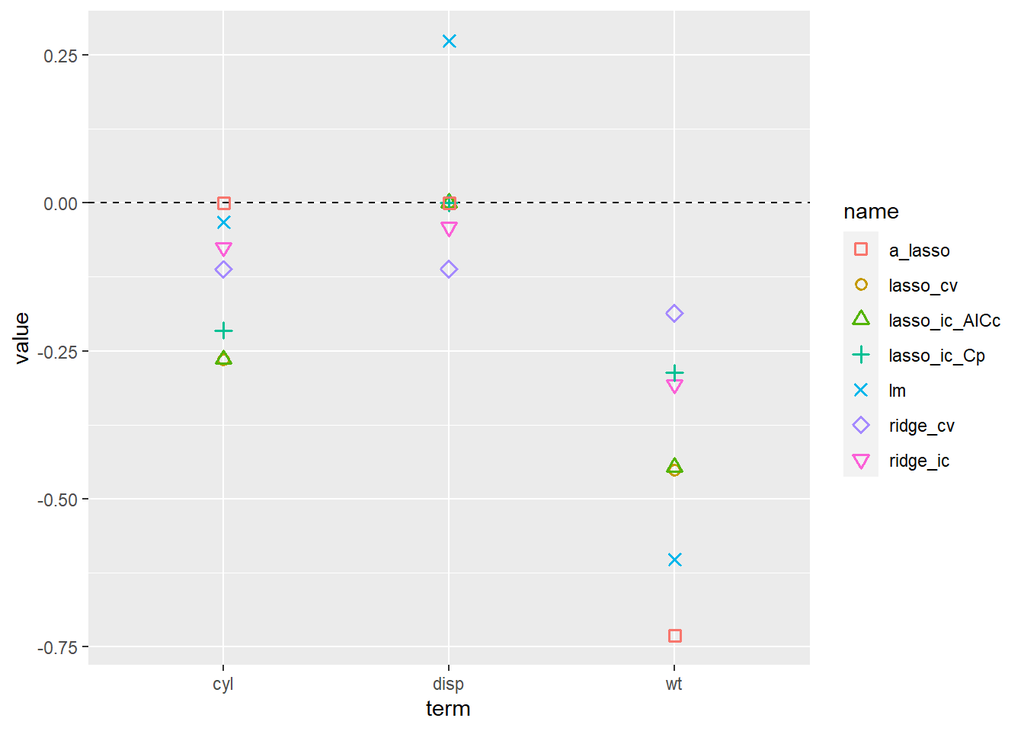

```r
coefs |>
  slice(-1) |>
  pivot_longer(!term) |>
  dplyr::filter(term %in% c("disp", "cyl", "wt")) |>
  mutate(value = replace_na(value, 0)) |>
  ggplot(aes(x = term, y = value, color = name, shape = name)) +
  geom_hline(yintercept = 0, linetype=2) +
  geom_point(size = 2, stroke = 1) +
  scale_shape_manual(values = 0:6)
```

なるほど、Ridgeではcylとdispに均等に重みが分けられている様子。

TOPへ戻る